# Spatial Analysis Assignment 4: Example

Jonathan Lee

9/28/2021

#### This example is meant to help you get started on assignment 4.

#### Load Libraries

```r
options(java.parameters = "-Xmx2G")

library(r5r)
library(osmextract)
library(tidyverse)
library(sf)
library(ggthemes)
library(ggspatial)
library(tigris)
library(wesanderson)
library(tidytransit)

# dir.create("networks")
```

#### Download the Boston GTFS file.

```r
# download.file("https://cdn.mbta.com/MBTA_GTFS.zip", file.path("networks","Bostongtfs.zip"), mode = "wb", quiet=TRUE)
```

#### Visualize the streets network in Boston

```r
boston_file <- oe_match("Boston")
```

```
## No exact match found for place = Boston and provider = geofabrik. Best match is Bhutan.
## Checking the other providers.
```

```
## No exact match found in any OSM provider data. Searching for the location online.
```

```
## The input place was matched with us/massachusetts.
```

#### You might get a error message like: “No exact match found for place = Boston…The input place was matched with us/massachusetts”

#### It means that since Boston wasn’t specifically available, it gave us the entire MA street network instead.

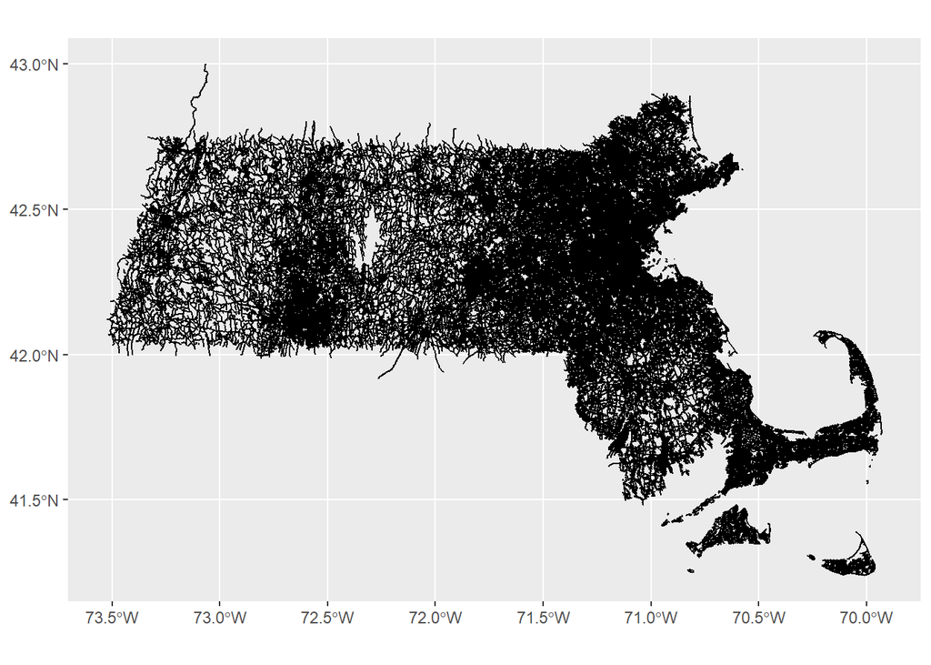

```r
boston_streets <- oe_read(boston_file$url,
                   provider = "openstreetmap_fr",
                   download_directory = "networks",
                   layer = "lines",
                   quiet = TRUE) %>%
  filter(!is.na(highway))

ggplot(boston_streets) +
  geom_sf()
```

#### We’ll have to get the Boston city boundaries and clip the road network. We can try getting the Boston city boundary polygon from the tigris library.

```r
boston_tigris <- places("Massachusetts")%>%
  filter(NAME == "Boston") %>%
  st_transform(crs = st_crs(boston_streets))
```

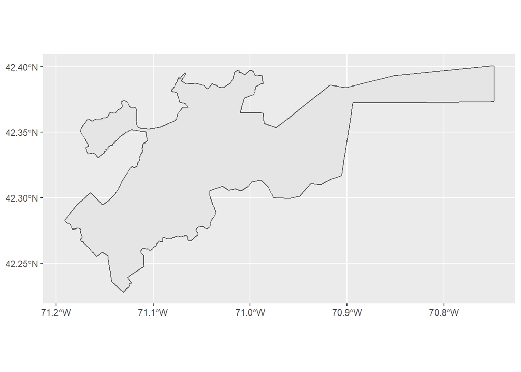

```r
ggplot(boston_tigris) +
  geom_sf()
```

```r
boston <- st_read("https://bostonopendata-boston.opendata.arcgis.com/datasets/142500a77e2a4dbeb94a86f7e0b568bc_9.geojson?outSR=%7B%22latestWkid%22%3A2249%2C%22wkid%22%3A102686%7D")
```

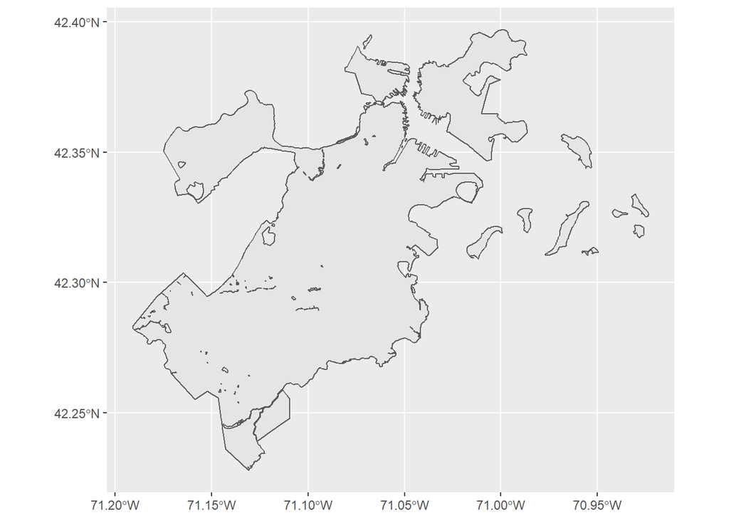

```r
ggplot(boston) +
  geom_sf()
```

#### Using this, we can cip the boston street network data, first making sure that they are on the same spatial projection.

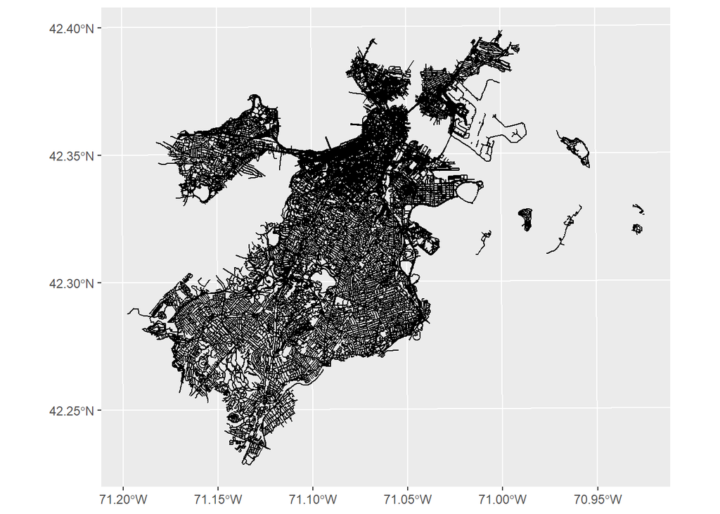

```r
MA_state_plane <- "+proj=lcc +lat_1=41.71666666666667 +lat_2=42.68333333333333 +lat_0=41 +lon_0=-71.5 +x_0=200000 +y_0=750000 +ellps=GRS80 +units=m +no_defs"

boston_streets <- boston_streets %>%
  st_transform(MA_state_plane)

boston <- boston %>%
  st_transform(MA_state_plane)

boston_streets <- boston_streets[boston,]

ggplot(boston_streets) +
  geom_sf()
```

#### Map of the street network in Boston. Typing in grDevices::colors() in the console will give you all the colors that you can plug in R.

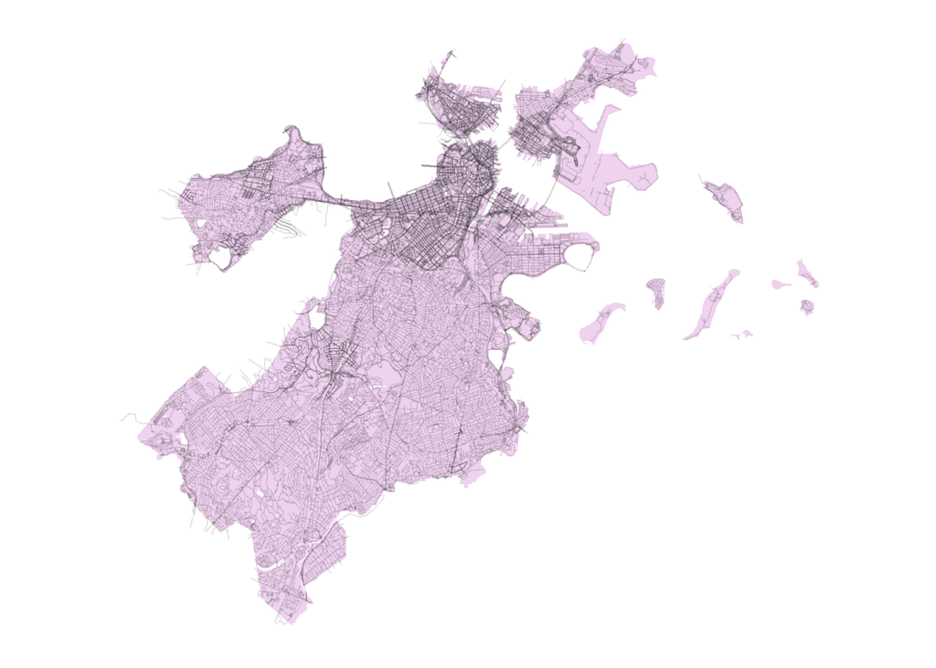

```r
ggplot() +
  geom_sf(data = boston, fill = "thistle2", color = NA) + ## "fill" is the inside color, "color" is outline
  geom_sf(data = boston_streets, alpha = 0.1) + ##You can adjust the opacity of each layer through alpha.
  theme_map()
```

#### Next, I’ll bring in point layer data.

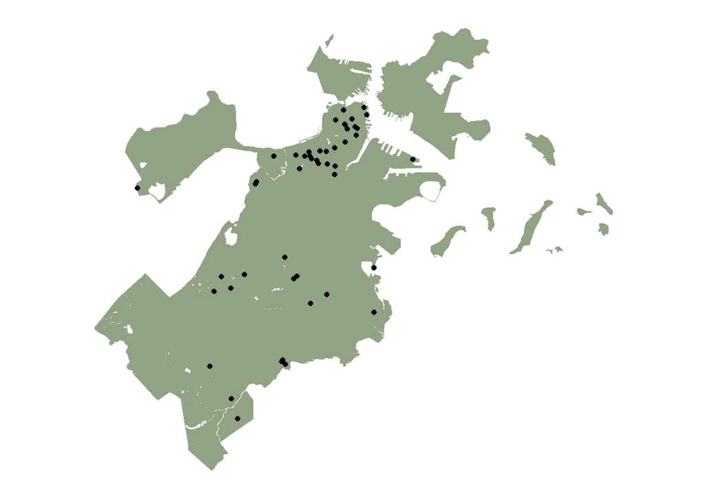

```r
boston_parking <- oe_read(boston_file$url,
                  provider = "openstreetmap_fr",
                  download_directory = "networks",
                  layer = "points",
                  quiet = TRUE) %>%
  filter(str_detect(other_tags, '"amenity"=>"parking"')) %>%
  st_transform(crs = MA_state_plane) %>%
  st_filter(boston) %>% ## Leaves only those within Boston boundaries
  rename(id = osm_id)

ggplot() +
  geom_sf(data = boston, fill = "#758B66", color = NA, alpha = 0.8) + ## You can also put in the HEX value of the color
  geom_sf(data = boston_parking)+
  theme_map()
```

#### Next, I’ll Set up the Boston grid.

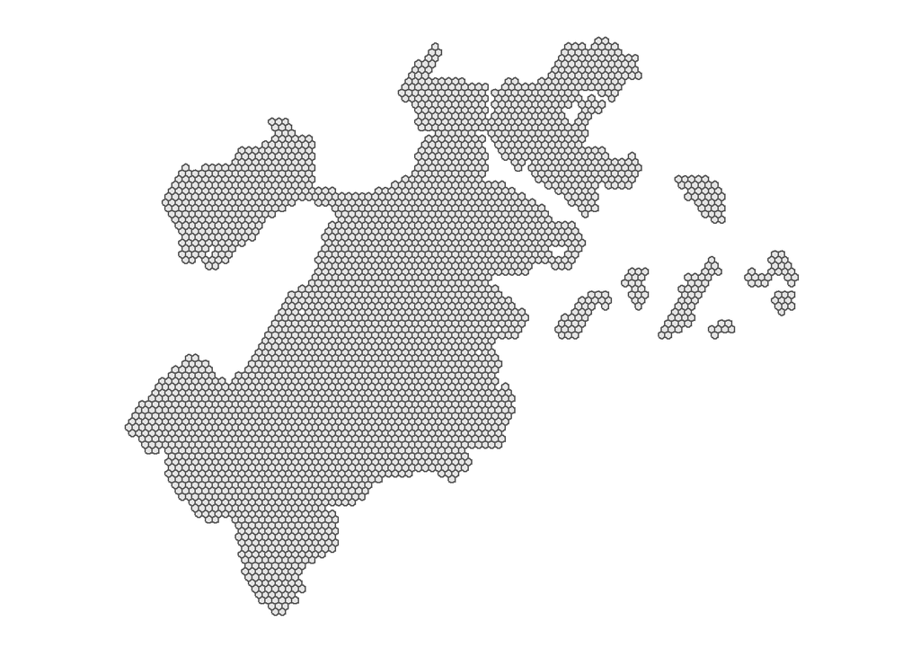

```r
grid <- st_sf(st_make_grid(boston, square = FALSE,
                           n = c(100, 100),
                           what = "polygons")) %>%
  st_filter(boston)

colnames(grid) <- "geometry"
st_geometry(grid) <- "geometry"

grid <- grid %>%
  mutate(id = seq(1, length(grid$geometry), by = 1))


ggplot() +
  geom_sf(data = grid)+
  theme_map()
```

#### I can make the grid into point data by getting the center of each polygon.

```r
grid_points <- st_centroid(grid)
```

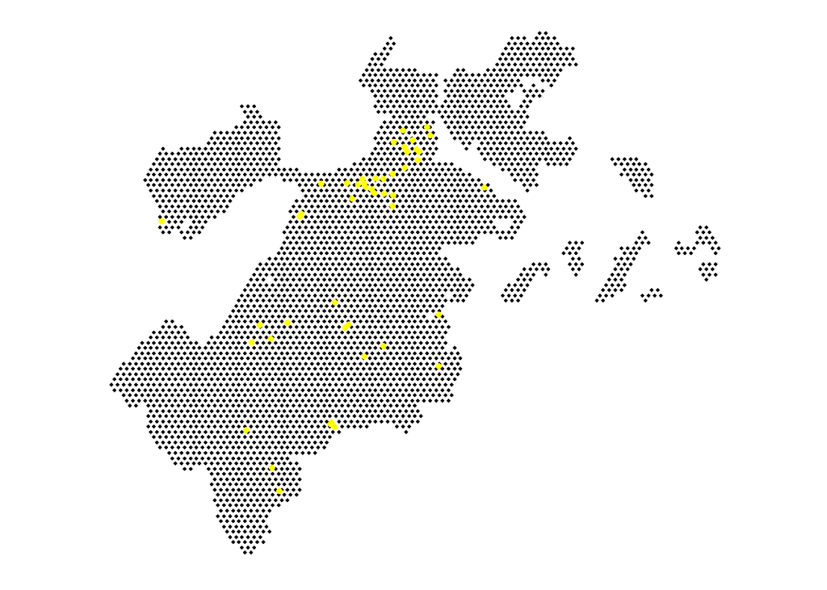

```r
ggplot() +
  geom_sf(data = grid_points, size = 0.75) +
  geom_sf(data = boston_parking, color = "yellow1") +
  theme_map()
```

#### Set up r5r

```r
r5r_core <- setup_r5("networks", verbose = FALSE)
```

```
## Using cached version from C:/Users/yedah/Documents/R/win-library/4.1/r5r/jar/r5-v6.2-all_20210408.jar
```

```
##
## Using cached network.dat from networks/network.dat
```

#### Calculate travel time matrix. Travel time is calculated through lat/long data NOT spatially projected data. So, origins and destinations point data must be converted back to lat/long format

```r
ttm <- travel_time_matrix(r5r_core = r5r_core,
                          origins = st_transform(x = boston_parking, crs = "WGS84"),
                          destinations = st_transform(x = grid_points, crs = "WGS84"),
                          mode = "WALK",
                          departure_datetime = as.POSIXct("15-11-2021 14:00:00",
                                 format = "%d-%m-%Y %H:%M:%S"),
                          max_walk_dist = 1000,
                          max_trip_duration = 480,
                          verbose = FALSE)
tt_wide <- ttm %>%
  pivot_wider(names_from = fromId,
              names_prefix = "from", values_from = travel_time) %>%
  rename(id = toId) %>%
  merge(grid) %>%
  replace(is.na(.), 999) %>%
  rowwise() %>%
  mutate(from_any = min(c_across(starts_with("from")), na.rm = TRUE))

st_geometry(tt_wide) <- "geometry"
```

#### Map of walking time to nearest parking structure in Boston. You can read more about how to use the Wes Anderson palette here: https://github.com/karthik/wesanderson

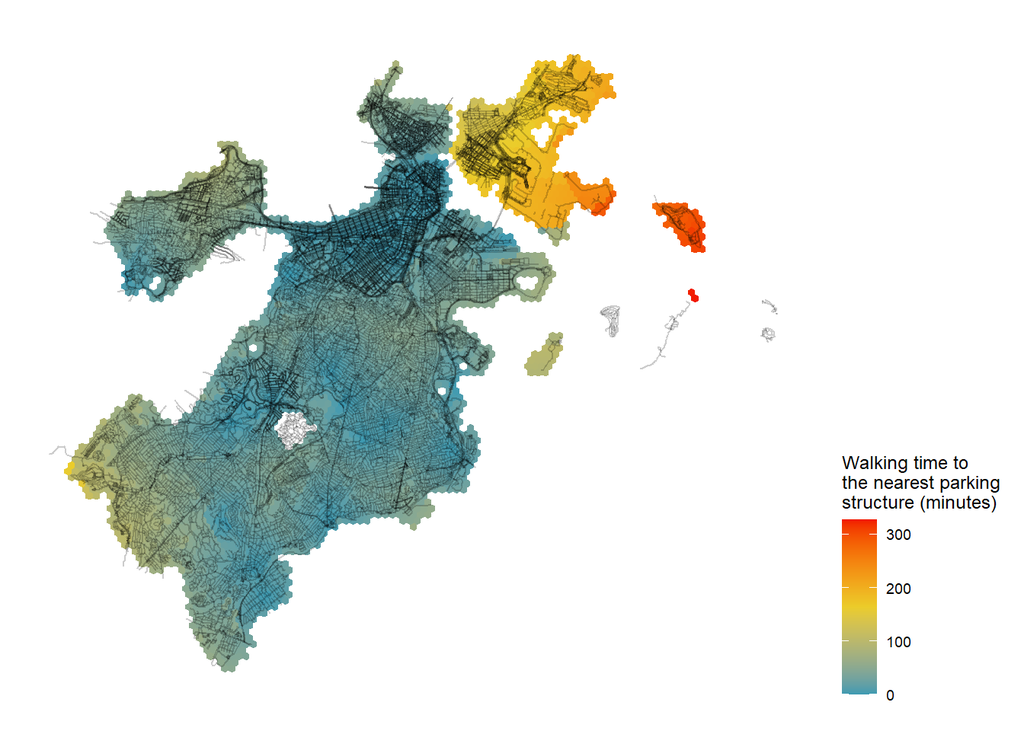

```r
ggplot() +
  geom_sf(data = tt_wide,
          aes(fill = from_any),
          color = NA) +
  geom_sf(data = boston_streets, alpha = 0.2) +
  scale_fill_gradientn(colors = wes_palette(name = "Zissou1", n= 3, type = "continuous"),
        name = "Walking time to\nthe nearest parking \nstructure (minutes)",
        position = "right") +
  coord_sf(crs = MA_state_plane) +
  theme_map()+
  theme(legend.position = "right")
```

```r
stop_r5(r5r_core)
```

```
## r5r_core has been successfully stopped.
```

```r
rJava::.jgc(R.gc = TRUE)
```